# Exp1_Online_Analysis_cgg

Mrudula & Carina

18/08/2020

### DATA CLEANING

The datafiles from 60 participants have been combined together to one file. NOw the datafile needs to be arranged and prepped to set it up for analysis

```r
#loading the necessary libraries
library(tidyverse)
library(plyr)
library(ez)
library(schoRsch)
library(lme4)#for multilevel modelling
library(nlme)
library(data.table)
library(knitr)#for markdown
library(pander)#for markdown tables
library(BayesFactor)

#clearing up workspace
rm(list=ls())

#setting up working directory at home office
#setwd("C:/FSU Jena_PhD/Exp1/Analysis")
#loading the combined datafile home office
#Exp1data_OL <- read.csv("C:/FSU Jena_PhD/Exp1/Data/Exp1-Prolific/Exp1data_online_fullset.csv")

#Office set up Mrudula
setwd("D:/PhD/Exp1-Overshadowing/Analysis/R Scripts")
#Office setup Carina
#setwd("~/Daten/1 BRAC-FOR/overshadowing/Exp 1 Psychopy Mrudula/Analyses")

#load from office
Exp1data_OL <- read.csv("D:/PhD/Exp1-Overshadowing/Data/Exp1data_online_fullset.csv")
```

Removing the columns that are not important such as thisN and thisRepN and so on.Next is to split the RT column because each column may contain more than one value and we only need to record the first RT response. RTs should also be changed to numberic as they are represented as strings initially

```r
#removing unnecessary columns

Exp1data_OL <- Exp1data_OL %>%
  select(-Attention.thisRepN,-Attention.thisTrialN,-Attention.thisIndex,-Attention.ran,
         -id, -session, -researcher, -InstRep.thisRepN,-InstRep.thisIndex,-InstRep.thisN, -InstRep.thisTrialN,
         -PracRepeat.thisRepN,-PracRepeat.thisIndex,-PracRepeat.thisN, -PracRepeat.thisTrialN,
         -prctrials.thisIndex,-prctrials.thisRepN,-prctrials.thisTrialN,-prctrials.ran,
         -firstlearntrials.thisN,-firstlearntrials.thisRepN,-firstlearntrials.thisTrialN,-firstlearntrials.ran,-firstlearntrials.thisIndex,
         -afterpause.keys,-blocks.thisRepN,-blocks.thisTrialN,-blocks.thisTrialN,-blocks.thisIndex,-blocks.ran,
         )
#removing the first column named x
Exp1data_OL <- subset(Exp1data_OL, select = -c(X))

#get RT variable to start of dataset
Exp1data_OL <-Exp1data_OL %>%
  select(ResponseKey.rt, PreTargetDisplayTime, Block, everything())


#Splitting up the RT column to be able to evaluate the RTs
Exp1data_OL <- separate(Exp1data_OL, col = ResponseKey.rt, into = c("RT_Trials", "RT_secondary"), sep = ",")
#removing the square bracket and changing from string to numeric
Exp1data_OL$RT_Trials <- Exp1data_OL$RT_Trials %>%
  str_replace_all("\\[|\\]", "")%>%
  as.numeric(Exp1data_OL$RT_Trials)
#converting RT and PreTarget DIsplay time values in ms
Exp1data_OL$RT_Trials <- 1000*(Exp1data_OL$RT_Trials)
Exp1data_OL$PreTargetDisplayTime <- 1000 * Exp1data_OL$PreTargetDisplayTime
#treating it like a double instead of integer
Exp1data_OL$RT_Trials <- as.double(Exp1data_OL$RT_Trials)

#renaming it to OldRT to have a copy and later transform the RT values based on the time calculated in psychopy
names(Exp1data_OL)[names(Exp1data_OL)=="RT_Trials"]<- "Old_RT"
Exp1data_OL$RT_Trials <- Exp1data_OL$Old_RT

#to check frequency of each value in the column
table(Exp1data_OL$PreTargetDisplayTime)
```

```
##
##  350  400  450  500  550
## 5973 5979 6099 5970 5979
```

```r
#adjusting RT
Exp1data_OL$RT_Trials <- 400+Exp1data_OL$RT_Trials #adding the 400ms that was coded in psychopy after which RT is evaluated
#Removing the preinterval display duration that also includes fixation duration

Exp1data_OL$RT_Trials <- Exp1data_OL$RT_Trials - Exp1data_OL$PreTargetDisplayTime

#making sure screenbg is entered in every cell
Exp1data_OL <- Exp1data_OL%>%group_by(participant)%>%fill(Screen_bg,.direction = "down")
```

##### Data Preparation

Since the data is now cleaned to an extent, next steps involves preparing the df *Clearly identify the ACC and RT columns* New column with error rate *Removing the practice trials - Keep ExpFirst learn and learn trials for previous occurence analysis* Remove AttentionCheck

```r
Exp1data_OL$ACC_Trials <- Exp1data_OL$ResponseKey.corr
#new columns for error rate
Exp1data_OL$ErrorRate <- 1 - Exp1data_OL$ACC_Trials
#removing practice trial and attention block
Exp1data_OL <- Exp1data_OL[!grepl("Practice", Exp1data_OL$Block),]
Exp1data_OL <- Exp1data_OL%>%
  select(-ResponseKey_p.keys,-ResponseKey_p.corr,-ResponseKey_p.rt,-Prac_start.keys,-Prac_start.rt,-pracend.keys,-pracend.rt)
#removing attention check
Exp1data_OL<-Exp1data_OL%>%
  filter(!(Solution %in% c("l", "d")))
#Making sure Experiment unneccessary columns are removed and no NA values are present for ACC and RT
Exp1data_OL<-Exp1data_OL%>%
  select(-InstRep.ran,-consentkey.keys,-consentkey.rt,-beginexp.keys,-beginexp.rt,-checkresp.corr,-checkresp.keys,-checkresp.rt,-Attention.thisN,-Question,-Solution,-gotoPrac.keys,-gotoPrac.rt,-PracRepeat.ran,-prctrials.thisN,-afterpause.rt,-blocks.thisN)


#get newly created vars to start of dataset
Exp1data_OL <-Exp1data_OL %>%
  select(RT_Trials,Old_RT, ACC_Trials, ErrorRate, everything())

#removing the rows that contain NA like the block end/pause screens of the exp
Exp1data_OL<- Exp1data_OL%>%drop_na(RT_Trials)
```

Saving this cleaned and prepared data frame

```r
#write.csv(Exp1data_OL, file = "Exp1data_Online_cleaned.csv")
```

#### Removing Outliers and Farouts

Columns will be created based on the farouts and outliers of the Reaction Time(Only individual based outliers/farouts)

```r
#removing RT values for the incorrect trials
Exp1data_OL$RT_Trials[Exp1data_OL$ACC_Trials==0] <- NA
#summary(Exp1data_OL$RT_Trials)
#mean RT for correct trials
pander(summary(Exp1data_OL$RT_Trials), style = 'rmarkdown', caption = "RT summary after removing incorrectTrials")
```

RT summary after removing incorrectTrials

| Min. | 1st Qu. | Median | Mean | 3rd Qu. | Max. | NA’s |
| --- | --- | --- | --- | --- | --- | --- |
| 35.19 | 491.9 | 559.2 | 596.8 | 645.3 | 7007 | 1364 |

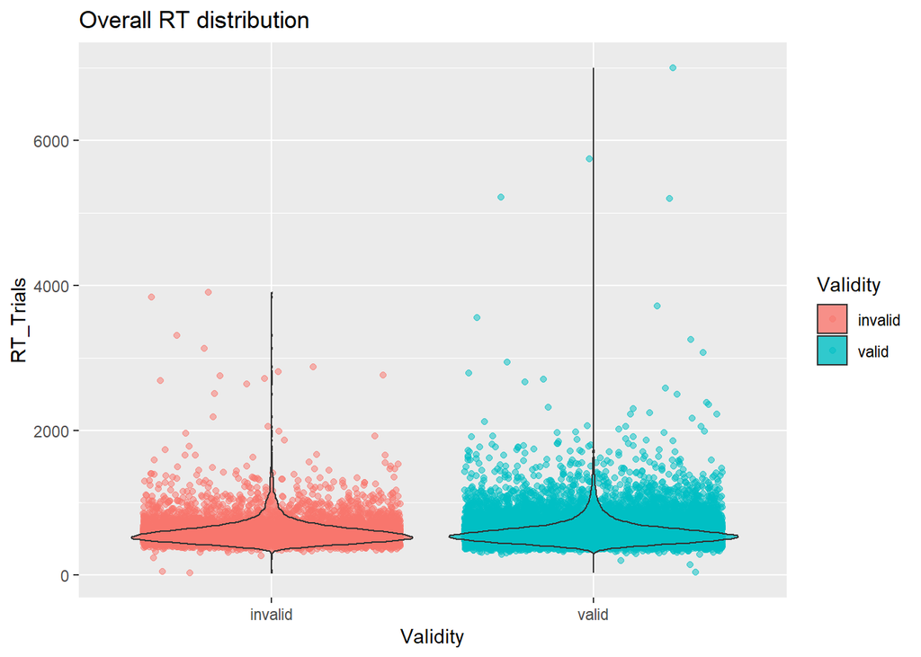

```r
#plotting the values to check for outliers

ggplot(Exp1data_OL, aes(x=Validity, y=RT_Trials))+
  geom_jitter(aes(color=Validity, fill = Validity), alpha = 0.5)+
  geom_violin(aes(fill=Validity), alpha = 0.8)+
  ggtitle("Overall RT distribution")
```

```r
#creating function to remove the outliers and farouts
computeTukeys <- function(x){
  P25 <- quantile(x$RT_Trials, .25, na.rm = TRUE, type = 6) #type = 6 -> used in SPSS
  P75 <- quantile(x$RT_Trials, .75, na.rm = TRUE, type = 6)
  x$Outlier <- P75 + 1.5*(P75 - P25)
  x$Farouts <- P75 + 3.0*(P75 - P25)
  return(x)
}


#identifying the outliers and farouts at individual level
Exp1data_OL <- ddply(Exp1data_OL, .(participant), computeTukeys)
```

Adding columns of RT based on the outliers/farouts being removed

```r
#check how fast the very fast RT are
#table(Exp1data_OL$RT_Trials)
#creating new column with RT trials after removing outliers/farouts
Exp1data_OL$RT_ifo <- Exp1data_OL$RT_Trials
Exp1data_OL$RT_io <- Exp1data_OL$RT_Trials
Exp1data_OL$RT_ifo[Exp1data_OL$RT_ifo > Exp1data_OL$Farouts|Exp1data_OL$RT_ifo < 300] <- NA
Exp1data_OL$RT_io[Exp1data_OL$RT_io > Exp1data_OL$Outlier|Exp1data_OL$RT_io < 300] <- NA

pander(summary(Exp1data_OL$RT_ifo), style = 'rmarkdown', caption = "Summary of RT after removing Farouts")
```

Summary of RT after removing Farouts

| Min. | 1st Qu. | Median | Mean | 3rd Qu. | Max. | NA’s |
| --- | --- | --- | --- | --- | --- | --- |
| 300.4 | 490.6 | 556.3 | 581.4 | 638.1 | 1619 | 1906 |

```r
pander(summary(Exp1data_OL$RT_io), style = 'rmarkdown', caption = "Summary of RT after removing Outliers")
```

Summary of RT after removing Outliers

| Min. | 1st Qu. | Median | Mean | 3rd Qu. | Max. | NA’s |
| --- | --- | --- | --- | --- | --- | --- |
| 300.4 | 488.2 | 552.9 | 568.1 | 626.8 | 1245 | 2874 |

```r
#Plotting to check farouts
# ggplot(Exp1data_OL, aes(x=Validity, y=RT_ifo))+
#   geom_jitter(aes(color=Validity, fill = Validity), alpha = 0.5)+
#   geom_violin(aes(fill=Validity), alpha = 0.8)+
#   facet_grid(.~Saliency)+
#   ggtitle("RT distribution after the Farouts have been removed")
#
# #plot for outliers
# ggplot(Exp1data_OL, aes(x=Validity, y=RT_io))+
#   geom_jitter(aes(color=Validity, fill = Validity), alpha = 0.5)+
#   geom_violin(aes(fill=Validity), alpha = 0.8)+
#   facet_grid(.~Saliency)+
#   ggtitle("RT distribution after the outliers have been removed")
```

## Computing Previous Occurence

After identifying Outliers and Farouts, now we move onto identifying the previous or last occurence of a specific Word. How many trials ago was the last time a particular Distractor word appeared?

```r
#alternatively, moving relevant columns to the first position(s) for even easier reference ;)
Exp1data_OL <- Exp1data_OL%>%select(Condition, Distractor1, Distractor2, everything())
```

Now, First step is to add a column that contains the value of how far the previous occurence was. It contains the lag variable. First step is to code the variables where the last occurence was the **immediately** preceding trial(where lag = 1).

```r
#For TEST Trials
#Giving a default value of far for the Distance column
Exp1data_OL$Distance <- NA
Exp1data_OL <- Exp1data_OL %>%
  mutate(Distance = ifelse(lag(Condition,1)=="test" &
              (lag(Distractor1,1)==Distractor1|lag(Distractor1,1)==Distractor2) &
                            lag(participant,1)==participant &
                            lag(ACC_Trials,1)== 1, 1, Distance))
#For LEARN trials
Exp1data_OL <- Exp1data_OL %>%
  mutate(Distance = ifelse(lag(Condition,1)=="learn" &                           (lag(Distractor1,1)==Distractor1|lag(Distractor1,1)==Distractor2|lag(Distractor2,1)==Distractor1) & lag(participant,1)==participant &  lag(ACC_Trials,1)== 1, 1, Distance))
```

```r
#The number of immediate previous occurences
pander(table(Exp1data_OL$Distance), style = 'rmarkdown', caption = "Table showing the number of immediate previous occurence")
```

Table showing the number of immediate previous occurence

| 1 |
| --- |
| 11024 |

```r
sum(is.na(Exp1data_OL$Distance))
```

[output not shown]

```r
lagvalue <- 2:30

#For learn trials and test trials together

for(j in lagvalue){
  Exp1data_OL <- Exp1data_OL %>%
    mutate(Distance = ifelse((lag(Condition,j)=="learn"|lag(Condition,j)=="test") &                     (lag(Distractor1,j)==Distractor1|lag(Distractor1,j)==Distractor2|lag(Distractor2,j)==Distractor1) & lag(participant,j)==participant & lag(ACC_Trials,j)== 1 & is.na(Distance)==TRUE, j, Distance))
}

pander(table(Exp1data_OL$Distance), style = 'rmarkdown', caption = "Table showing the number of total previous occurences and how far each of them are")
```

Table showing the number of total previous occurences and how far each of them are (continued below)

| 1 | 2 | 3 | 4 | 5 | 6 | 7 | 8 | 9 | 10 | 11 |
| --- | --- | --- | --- | --- | --- | --- | --- | --- | --- | --- |
| 11024 | 7216 | 4425 | 2782 | 1577 | 928 | 466 | 247 | 142 | 50 | 39 |

| 12 | 13 | 14 |
| --- | --- | --- |
| 12 | 1 | 4 |

```r
sum(is.na(Exp1data_OL$Distance))
```

```
## [1] 127
```

## Previous response

To check whether the response was repeated or different w.r.t to the previous trial First, creating another column that contains the values “RR” or “RC” based on whether the response is repeated or changed respectively. *Using lag function to look back at trials to check whether the response was same or different the last time that occurence happened. +If for example the previous time Tisch|Kreis occured was a valid test trial 3 rows back where the response expected was “l” then the responsetype column would have the value “RR”

```r
Exp1data_OL$ResponseType <- NA
#moving this column to the last for easy reference
Exp1data_OL <- Exp1data_OL%>%select(CorrectAnswer,everything())

#coding repeating the same response and if the conditions are not true the RC is evaluated under the else clause within the main ifelse statement. This was done to avoid revaluating and missing out values that are originally RC but was treated as RR as that was evaluated first.
Rmlag <- 1:30
for(k in Rmlag){
Exp1data_OL <- Exp1data_OL %>%
  mutate(ResponseType = ifelse((lag(Condition,k)=="learn" | lag(Condition,k)=="test") &          (lag(Distractor1,k)==Distractor1|lag(Distractor1,k)==Distractor2|lag(Distractor2,k)==Distractor1) & lag(participant,k)==participant & lag(CorrectAnswer,k)== CorrectAnswer & is.na(ResponseType)==TRUE, "RR", ifelse((lag(Condition,k)=="learn"|lag(Condition,k)=="test") & (lag(Distractor1,k)==Distractor1|lag(Distractor1,k)==Distractor2|lag(Distractor2,k)==Distractor1)& lag(participant,k)==participant & lag(CorrectAnswer,k)!= CorrectAnswer & is.na(ResponseType)==TRUE, "RC", ResponseType)))
}

pander(table(Exp1data_OL$ResponseType),style = 'rmarkdown', caption = "Total number of RRs and RCs")
```

Total number of RRs and RCs

| RC | RR |
| --- | --- |
| 12382 | 16538 |

```r
sum(is.na(Exp1data_OL$ResponseType))
```

```
## [1] 120
```

```r
#crosstable to check factorial combination of Distance x Response Type:
pander(table(Exp1data_OL$Distance, Exp1data_OL$ResponseType), style = 'rmarkdown', caption = 'Factorial combination of Distance x Response Type')
```

Factorial combination of Distance x Response Type

| RC | RR |
| --- | --- |
| 4472 | 6552 |
| 3026 | 4190 |
| 1910 | 2515 |
| 1247 | 1535 |
| 745 | 832 |
| 476 | 452 |
| 238 | 228 |
| 130 | 117 |
| 76 | 66 |
| 27 | 23 |
| 23 | 16 |
| 5 | 7 |
| 1 | 0 |
| 4 | 0 |

```r
#crosstable to check factorial combination of Distance x Response Type x COndition:
pander(table(Exp1data_OL$Distance, Exp1data_OL$ResponseType, Exp1data_OL$Condition), caption = "Factorial combination of Distance x ResponseType x Condition")
```

Factorial combination of Distance x ResponseType x Condition

|  |  |  | learn | test |
| --- | --- | --- | --- | --- |
| 1 | RC |  | 1818 | 2654 |
|  | RR |  | 4689 | 1863 |
| 2 | RC |  | 1046 | 1980 |
|  | RR |  | 2821 | 1369 |
| 3 | RC |  | 573 | 1337 |
|  | RR |  | 1493 | 1022 |
| 4 | RC |  | 295 | 952 |
|  | RR |  | 825 | 710 |
| 5 | RC |  | 162 | 583 |
|  | RR |  | 400 | 432 |
| 6 | RC |  | 73 | 403 |
|  | RR |  | 168 | 284 |
| 7 | RC |  | 29 | 209 |
|  | RR |  | 71 | 157 |
| 8 | RC |  | 8 | 122 |
|  | RR |  | 25 | 92 |
| 9 | RC |  | 3 | 73 |
|  | RR |  | 10 | 56 |
| 10 | RC |  | 0 | 27 |
|  | RR |  | 3 | 20 |
| 11 | RC |  | 1 | 22 |
|  | RR |  | 1 | 15 |
| 12 | RC |  | 0 | 5 |
|  | RR |  | 1 | 6 |
| 13 | RC |  | 0 | 1 |
|  | RR |  | 0 | 0 |
| 14 | RC |  | 0 | 4 |
|  | RR |  | 0 | 0 |

```r
Exp1data_OL <- Exp1data_OL%>%
  select(Distance,ResponseType, everything())
```

```r
# ##FAROUTS
# ggplot(Exp1data_OL, aes(x=ResponseType, y=RT_ifo))+
#   geom_violin(aes(fill = Validity), alpha = 0.2)+
#   geom_point(aes(colour=Validity, group = Validity),position = position_jitterdodge())+
#   ylab("Reaction Time")+
#   facet_grid(.~Saliency)+
#   theme_classic()+
#   ggtitle("Distribution of RT(farouts) based on Response Type for all trials")
#
# Exp1data_OL %>% filter(Distance == 1) %>%
#   ggplot(aes(ResponseType,RT_ifo))+
#   geom_violin(aes(fill = Validity), alpha = 0.2)+
#   geom_point(aes(colour=Validity, group = Validity),position = position_jitterdodge())+
#   ylab("Reaction Time")+
#   facet_grid(.~Saliency)+
#   theme_classic()+
#   ggtitle("Distribution of RT(farouts) based on Response Type only for immediate occurrences")
#
# ##OUtliers
# ggplot(Exp1data_OL, aes(x=ResponseType, y=RT_io))+
#   geom_violin(aes(fill = Validity), alpha = 0.2)+
#   geom_point(aes(colour=Validity, group = Validity),position = position_jitterdodge())+
#   ylab("Reaction Time")+
#   facet_grid(.~Saliency)+
#   theme_classic()+
#   ggtitle("Distribution of RT(outliers) based on Response Type for all trials")
#
# Exp1data_OL %>% filter(Distance == 1) %>%
#   ggplot(aes(ResponseType,RT_io))+
#   geom_violin(aes(fill = Validity), alpha = 0.2)+
#   geom_point(aes(colour=Validity, group = Validity),position = position_jitterdodge())+
#   ylab("Reaction Time")+
#   facet_grid(.~Saliency)+
#   theme_classic()+
#   ggtitle("Distribution of RT(outliers) based on Response Type only for immediate occurrences")
```

Adding a column that checks what condition the last occurence was

```r
#creating new column
Exp1data_OL$LastOcc_Condition <- NA


Exp1data_OL <- Exp1data_OL %>%
  mutate(LastOcc_Condition = ifelse(lag(Condition,1)=="test" &
              (lag(Distractor1,1)==Distractor1|lag(Distractor1,1)==Distractor2) &
                            lag(participant,1)==participant &
                            lag(ACC_Trials,1)== 1, "test", LastOcc_Condition))

Exp1data_OL <- Exp1data_OL %>%
  mutate(LastOcc_Condition = ifelse(lag(Condition,1)=="learn" &
              (lag(Distractor1,1)==Distractor1|lag(Distractor1,1)==Distractor2) &
                            lag(participant,1)==participant &
                            lag(ACC_Trials,1)== 1, "learn", LastOcc_Condition))

#Checking the condition for each lag
for(l in lagvalue){
Exp1data_OL <- Exp1data_OL %>%
  mutate(LastOcc_Condition = ifelse((lag(Condition,l)=="learn") &          (lag(Distractor1,l)==Distractor1|lag(Distractor1,l)==Distractor2|lag(Distractor2,l)==Distractor1) & lag(participant,l)==participant & lag(ACC_Trials,l)==1 & is.na(LastOcc_Condition)==TRUE, "learn", ifelse((lag(Condition,l)=="test") & (lag(Distractor1,l)==Distractor1|lag(Distractor1,l)==Distractor2|lag(Distractor2,l)==Distractor1)& lag(participant,l)==participant & lag(ACC_Trials,l)== 1 & is.na(LastOcc_Condition)==TRUE, "test", LastOcc_Condition)))
}


table(Exp1data_OL$LastOcc_Condition)
```

```
##
## learn  test
## 17225 11688
```

```r
Exp1data_OL <- Exp1data_OL %>%
  select(LastOcc_Condition,everything())
```

## **STATISTICAL ANALYSIS**

Now for further analysis, the learn trials will be removed and only the test trials will be analysed

```r
#easy reference
Exp1data_OL <- Exp1data_OL%>%select(Saliency, Validity, everything())
Exp1data_OL <- Exp1data_OL%>%select(Distance, ResponseType, everything())
#check design
#table(Exp1data_OL$Condition, Exp1data_OL$Saliency)

Exp1data_OL <- Exp1data_OL[!grepl("learn", Exp1data_OL$Condition),]
table(Exp1data_OL$Condition)
```

```
##
## learn  test
##     0 14400
```

```r
table(Exp1data_OL$Screen_bg)
```

```
##
## black white
##  7680  6720
```

```r
table(Exp1data_OL$LastOcc_Condition)
```

```
##
## learn  test
## 10734  3664
```

```r
table(Exp1data_OL$WordPair)
```

```
##
##    1    2    3    4
## 2880 3600 3600 4320
```

#explore data: participants with many slow and/or erroneous resp? ####

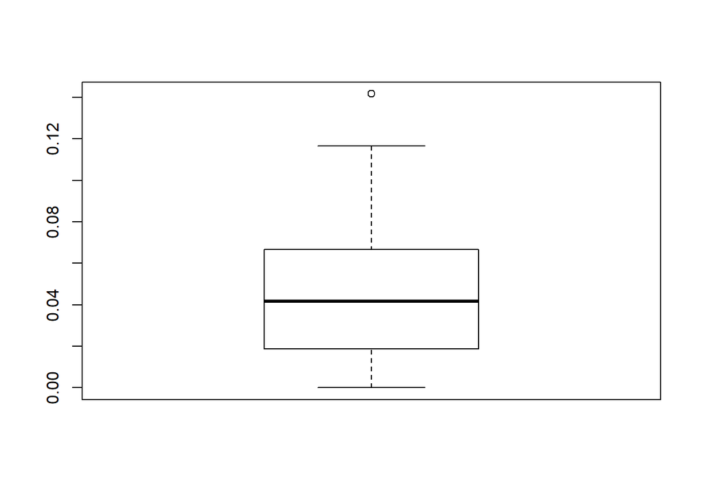

```r
#aggregate error rate per participant
aggErr <- aggregate(data = Exp1data_OL, ErrorRate ~ participant, mean)
#Boxplot
boxplot((aggErr$ErrorRate))
```

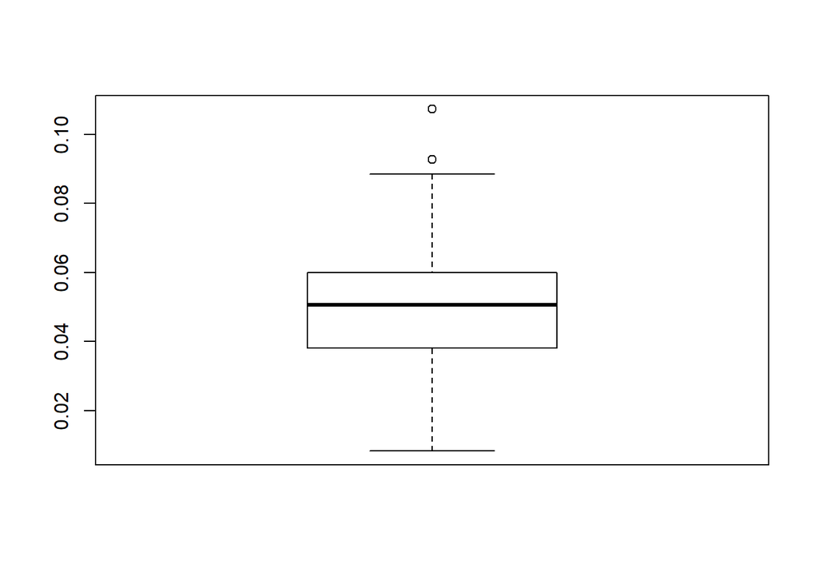

```r
#count RToutlier/farouts per participant
Exp1data_OL$count_io <-ifelse(Exp1data_OL$RT_Trials>Exp1data_OL$Outlier,1,0)
Exp1data_OL$count_ifo <-ifelse(Exp1data_OL$RT_Trials>Exp1data_OL$Farouts,1,0)

#check
Exp1data_OL<-Exp1data_OL%>%select(count_io, Outlier, RT_Trials, everything())


agg_io <- aggregate(data = Exp1data_OL, count_io ~ participant, mean)
boxplot(agg_io$count_io)
```

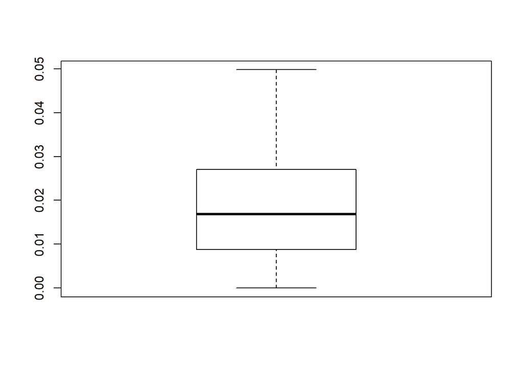

```r
agg_ifo <- aggregate(data = Exp1data_OL, count_ifo ~ participant, mean)
boxplot(agg_ifo$count_ifo)
```

#### 1. Aggregate the means with the factors ResponseType, Distance, Saliency, Validity

Creating a dataframe with the Mean RT across the factors of saliency and validity along with ResponseType and Distance. Separately for farouts and outliers so that it can be distinguised while performaning analysis

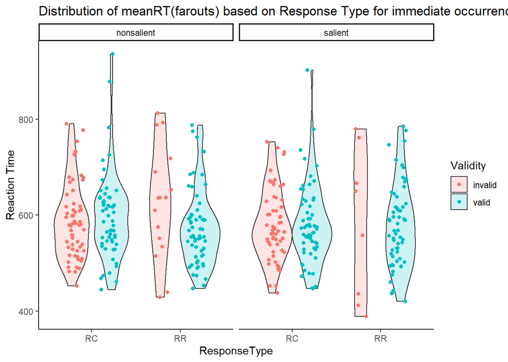

```r
#farouts
Exp1agg_fo <- aggregate(data = Exp1data_OL, RT_ifo~participant+Saliency+Validity+ResponseType+Distance, mean)

aggDistRespSV <- ddply(Exp1agg_fo, .(Validity,Saliency,ResponseType), summarize, RTmean=mean(RT_ifo))



#Check RT distribution for immediate occurences

Exp1agg_fo %>% filter(Distance == 1) %>%
  ggplot(aes(x=ResponseType, y=RT_ifo))+
  geom_violin(aes(fill = Validity), alpha = 0.2)+
  geom_point(aes(colour=Validity, group = Validity),position = position_jitterdodge())+
  ylab("Reaction Time")+
  facet_grid(.~Saliency)+
  theme_classic()+
  ggtitle("Distribution of meanRT(farouts) based on Response Type for immediate occurrences")
```

```r
pander(table(Exp1agg_fo$Distance, Exp1agg_fo$ResponseType),style = 'rmarkdown', caption = "Distance x ResponseType")
```

Distance x ResponseType

| RC | RR |
| --- | --- |
| 235 | 144 |
| 229 | 152 |
| 220 | 146 |
| 206 | 142 |
| 184 | 141 |
| 162 | 126 |
| 118 | 90 |
| 87 | 66 |
| 56 | 44 |
| 24 | 18 |
| 20 | 14 |
| 5 | 5 |
| 1 | 0 |
| 4 | 0 |

```r
#Converting to factors for ANOVA
Exp1agg_fo$participant <- as.factor(Exp1agg_fo$participant)
Exp1agg_fo$Saliency <- as.factor(Exp1agg_fo$Saliency)
Exp1agg_fo$Validity <- as.factor(Exp1agg_fo$Validity)
Exp1agg_fo$ResponseType <- as.factor(Exp1agg_fo$ResponseType)
Exp1agg_fo$Distance <- as.factor(Exp1agg_fo$Distance)



###outliers
Exp1agg_o <- aggregate(data = Exp1data_OL, RT_io~participant+Saliency+Validity+ResponseType+Distance, mean)


aggDistRespSV_o<- ddply(Exp1agg_o, .(Validity,Saliency,ResponseType), summarize, RTmean = mean(RT_io))


table(Exp1agg_o$participant)
```

```
##
##   6   7   8   9  10  11  12  13  82 131 219 295 323 324 325 326 327 329
##  46  45  39  42  45  46  50  47  42  44  49  44  44  41  44  45  41  50
## 331 332 337 338 339 340 341 342 343 345 348 351 354 355 357 362 363 365
##  39  43  41  42  47  39  40  50  40  43  41  42  45  43  47  42  47  44
## 366 367 370 372 373 374 375 376 377 378 379 380 385 386 387 388 389 390
##  41  43  38  44  42  43  41  42  40  50  43  39  48  49  42  44  38  44
## 391 392 393 396 397 398
##  42  50  44  43  43  38
```

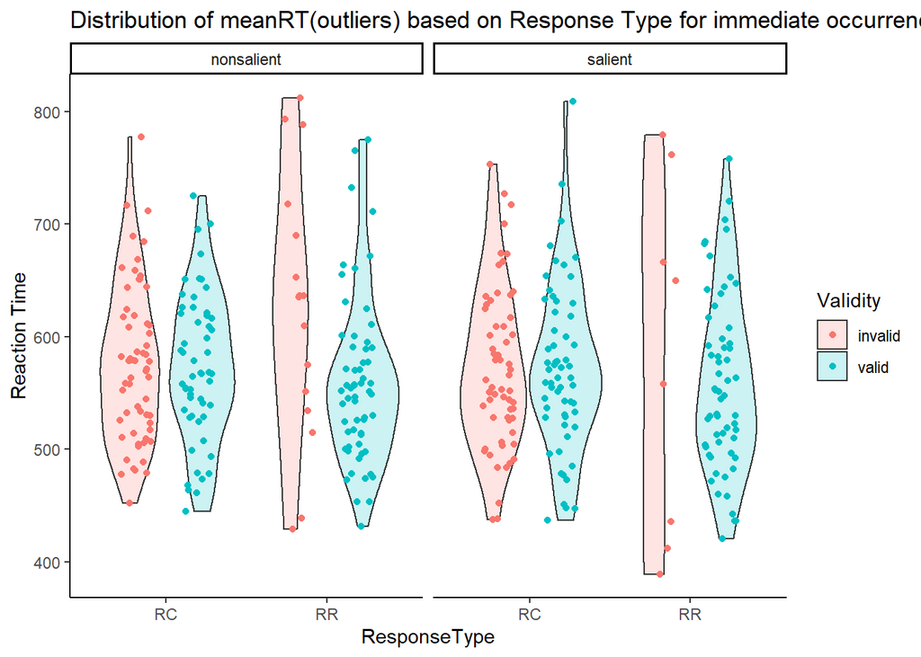

```r
#Exp1agg_o <- Exp1agg_o %>%
  #filter(Distance == 1)

#pander(table(Exp1agg_o$Distance, Exp1agg_o$ResponseType),style = 'rmarkdown', caption = "Distance x ResponseType")

#Converting to factors for ANOVA
Exp1agg_o$participant <- as.factor(Exp1agg_o$participant)
Exp1agg_o$Saliency <- as.factor(Exp1agg_o$Saliency)
Exp1agg_o$Validity <- as.factor(Exp1agg_o$Validity)
Exp1agg_o$ResponseType <- as.factor(Exp1agg_o$ResponseType)
#Exp1agg_o$Distance <- as.factor(Exp1agg_o$Distance)

#Plotting to check how the RT changes with ResponseType
Exp1agg_o %>% filter(Distance ==1) %>%
  ggplot(aes(x=ResponseType, y=RT_io))+
  geom_violin(aes(fill = Validity), alpha = 0.2)+
  geom_point(aes(colour=Validity, group = Validity),position = position_jitterdodge())+
  ylab("Reaction Time")+
  facet_grid(.~Saliency)+
  theme_classic()+
  ggtitle("Distribution of meanRT(outliers) based on Response Type for immediate occurrences")
```

```r
table(Exp1agg_o$participant, Exp1agg_o$RT_io)
```

[output not shown]

[output cut: 26026 more lines]

```r
table(Exp1agg_o$participant)
```

```
##
##   6   7   8   9  10  11  12  13  82 131 219 295 323 324 325 326 327 329
##  46  45  39  42  45  46  50  47  42  44  49  44  44  41  44  45  41  50
## 331 332 337 338 339 340 341 342 343 345 348 351 354 355 357 362 363 365
##  39  43  41  42  47  39  40  50  40  43  41  42  45  43  47  42  47  44
## 366 367 370 372 373 374 375 376 377 378 379 380 385 386 387 388 389 390
##  41  43  38  44  42  43  41  42  40  50  43  39  48  49  42  44  38  44
## 391 392 393 396 397 398
##  42  50  44  43  43  38
```

```r
sum(is.na(Exp1agg_o$RT_io))
```

```
## [1] 0
```

```r
##THROWS ERROR HAVE TO CHECK
#aggregate means of farouts without distance and REsponse Type
# #aggmeanSV_o <- ezStats(data = Exp1agg_o,
#                       dv = RT_io,
#                       wid = participant,
#                       within = .(Saliency, Validity,ResponseType))
```

#### 2. Aggregate means for Standard Analysis : Withouth Response Type and Distance

Aggregating the measn without the factors or Response Type and Distance to perform basic Standard analysis and check for contingency

```r
#farouts
Exp1agg_Standard_fo <- aggregate(data = Exp1data_OL, RT_ifo~participant+Saliency+Validity, mean)
#convert to factors for ANOVA
Exp1agg_Standard_fo$participant <- as.factor(Exp1agg_Standard_fo$participant)
Exp1agg_Standard_fo$Saliency <- as.factor(Exp1agg_Standard_fo$Saliency)
Exp1agg_Standard_fo$Validity <- as.factor(Exp1agg_Standard_fo$Validity)


#aggregate means of farouts
aggmeanSV_fo <- ezStats(data = Exp1agg_Standard_fo,
                     dv = RT_ifo,
                     wid = participant,
                     within = .(Saliency, Validity))
##OUTLIERS
Exp1agg_Standard_o <- aggregate(data = Exp1data_OL, RT_io~participant+Saliency+Validity, mean)

#Converting to factors for ANOVA
Exp1agg_Standard_o$participant <- as.factor(Exp1agg_Standard_o$participant)
Exp1agg_Standard_o$Saliency <- as.factor(Exp1agg_Standard_o$Saliency)
Exp1agg_Standard_o$Validity <- as.factor(Exp1agg_Standard_o$Validity)


#aggregate means of farouts
aggmeanSV_o <- ezStats(data = Exp1agg_Standard_o,
                     dv = RT_io,
                     wid = participant,
                     within = .(Saliency, Validity))
```

#### 3. Bin Analysis

```r
#Splitting theRT distribution in quartiles to check whether the speed of RT shows differences in validity effect
#outliers
Exp1data_OL$Quantiles <- ntiles(Exp1data_OL,
                                dv = "RT_Trials",
                                bins = 4)

binagg <-  aggregate(data = Exp1data_OL, RT_ifo~participant+Saliency+Validity+Quantiles, mean)
binanova <- aov(RT_ifo~Validity+Quantiles+Saliency+Validity*Saliency, data = binagg)
summary(binanova)
```

```
##                    Df   Sum Sq  Mean Sq   F value Pr(>F)
## Validity            1      120      120     0.106  0.745
## Quantiles           1 11919104 11919104 10529.268 <2e-16 ***
## Saliency            1     1043     1043     0.921  0.337
## Validity:Saliency   1       14       14     0.012  0.911
## Residuals         937  1060682     1132
## ---
## Signif. codes:  0 '***' 0.001 '**' 0.01 '*' 0.05 '.' 0.1 ' ' 1
```

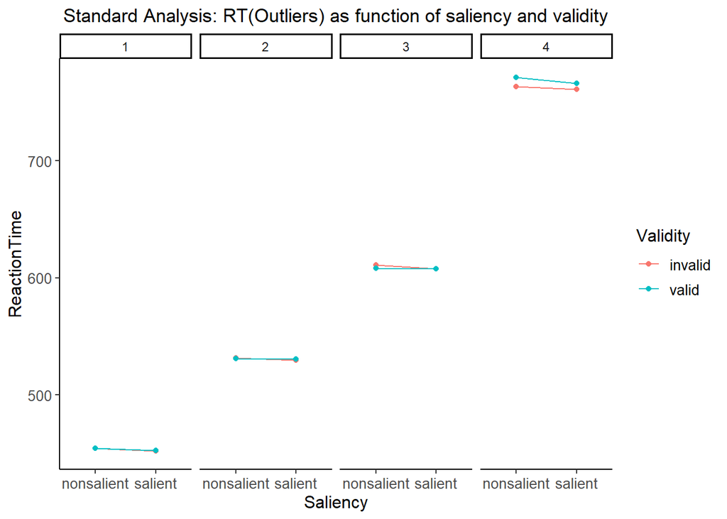

```r
meanbin <- ddply(binagg, .(Validity,Saliency,Quantiles), summarize, mean=mean(RT_ifo))
ggplot(meanbin, aes(x=Saliency, color=Validity, y=mean))+
  geom_line(aes(group=Validity))+
  geom_point()+
  labs(x="Saliency", y = "ReactionTime")+
  theme_classic()+
  facet_grid(.~Quantiles)+
  ggtitle("Standard Analysis: RT(Outliers) as function of saliency and validity")+
  theme(plot.title = element_text(hjust = 0.5))+
  theme(legend.title = element_text(size=12), legend.text= element_text(size=10))+
  theme(axis.title = element_text(size=12),axis.text = element_text(size=10))
```

## *ANOVA & PLOTS*

#### 1. Standard Analysis ANOVA with plot

```r
#using ezPackage
standard_anova_fo <- ezANOVA(Exp1agg_Standard_fo,
                    dv = RT_ifo,
                    wid = participant,
                    within = .(Saliency,Validity),
                    detailed = TRUE)
anova_out(standard_anova_fo)
```

```
## $`--- ANOVA RESULTS     ------------------------------------`
##              Effect        MSE df1 df2       F     p petasq getasq
## 1       (Intercept) 21485.6098   1  59 3750.76 0.000   0.98   0.98
## 2          Saliency   197.4958   1  59    0.05 0.816   0.00   0.00
## 3          Validity   202.7506   1  59    0.11 0.744   0.00   0.00
## 4 Saliency:Validity   297.0224   1  59    1.41 0.240   0.02   0.00
##
## $`--- SPHERICITY TESTS  ------------------------------------`
## [1] "N/A"
##
## $`--- FORMATTED RESULTS ------------------------------------`
##              Effect                                    Text
## 1       (Intercept) F(1, 59) = 3750.76, p < .001, np2 = .98
## 2          Saliency F(1, 59) =    0.05, p = .816, np2 < .01
## 3          Validity F(1, 59) =    0.11, p = .744, np2 < .01
## 4 Saliency:Validity F(1, 59) =    1.41, p = .240, np2 = .02
##
## $`NOTE:`
## [1] "Reporting unadjusted p-values."
```

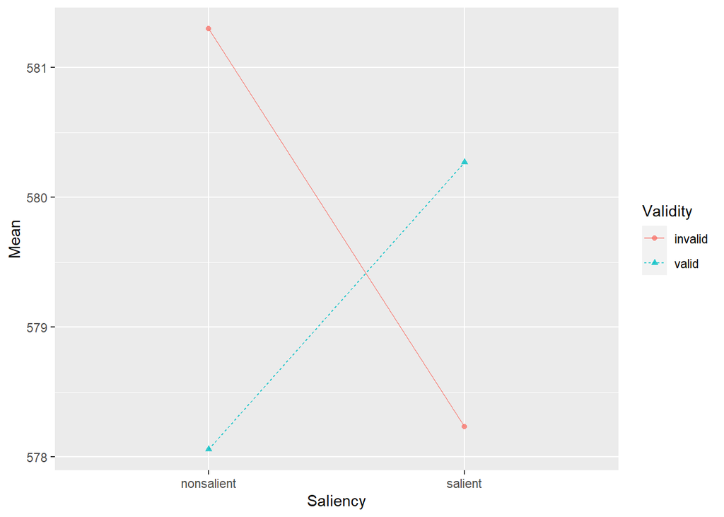

```r
#plot
ezPlot(Exp1agg_Standard_fo,
                    dv = RT_ifo,
                    wid = participant,
                    within = .(Saliency,Validity),
                    split=Validity,
                    x = Saliency,
                    do_bars = F)
```

```r
panderOptions('table.split.table',300)
pander(standard_anova_fo, style = 'rmarkdown', caption = "Standard ANOVA table: RT(farouts) as a function of Saliency and Validity", split.table = Inf)
```

- **ANOVA**:

  | Effect | DFn | DFd | SSn | SSd | F | p | p<.05 | ges |
  | --- | --- | --- | --- | --- | --- | --- | --- | --- |
  | (Intercept) | 1 | 59 | 80587260 | 1267651 | 3751 | 4.184e-55 | * | 0.984 |
  | Saliency | 1 | 59 | 10.85 | 11652 | 0.05492 | 0.8155 |  | 8.287e-06 |
  | Validity | 1 | 59 | 21.77 | 11962 | 0.1074 | 0.7443 |  | 1.664e-05 |
  | Saliency:Validity | 1 | 59 | 417.6 | 17524 | 1.406 | 0.2405 |  | 0.000319 |

```r
#outliers
standard_anova_o <- ezANOVA(data = Exp1agg_Standard_o,
                    dv = RT_io,
                    wid = participant,
                    within = .(Saliency,Validity),
                    detailed = TRUE)
anova_out(standard_anova_o)
```

```
## $`--- ANOVA RESULTS     ------------------------------------`
##              Effect        MSE df1 df2       F     p petasq getasq
## 1       (Intercept) 18769.2852   1  59 4114.38 0.000   0.99   0.99
## 2          Saliency   139.5608   1  59    0.03 0.858   0.00   0.00
## 3          Validity   140.2357   1  59    1.33 0.253   0.02   0.00
## 4 Saliency:Validity   184.9455   1  59    0.45 0.505   0.01   0.00
##
## $`--- SPHERICITY TESTS  ------------------------------------`
## [1] "N/A"
##
## $`--- FORMATTED RESULTS ------------------------------------`
##              Effect                                    Text
## 1       (Intercept) F(1, 59) = 4114.38, p < .001, np2 = .99
## 2          Saliency F(1, 59) =    0.03, p = .858, np2 < .01
## 3          Validity F(1, 59) =    1.33, p = .253, np2 = .02
## 4 Saliency:Validity F(1, 59) =    0.45, p = .505, np2 = .01
##
## $`NOTE:`
## [1] "Reporting unadjusted p-values."
```

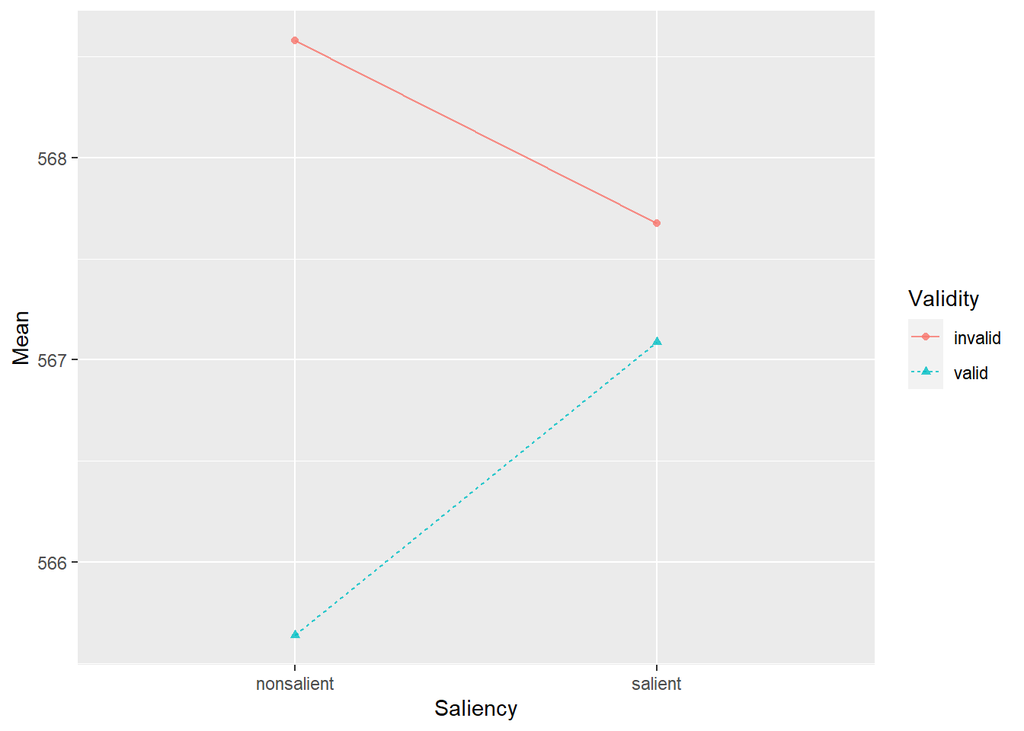

```r
ezPlot(Exp1agg_Standard_o,
                    dv = RT_io,
                    wid = participant,
                    within = .(Saliency,Validity),
                    split=Validity,
                    x = Saliency,
                    do_bars = F)
```

Plots of the data for both outliers and farouts of the ** Standard Analysis data set ** including only the Saliency and Validity as factors

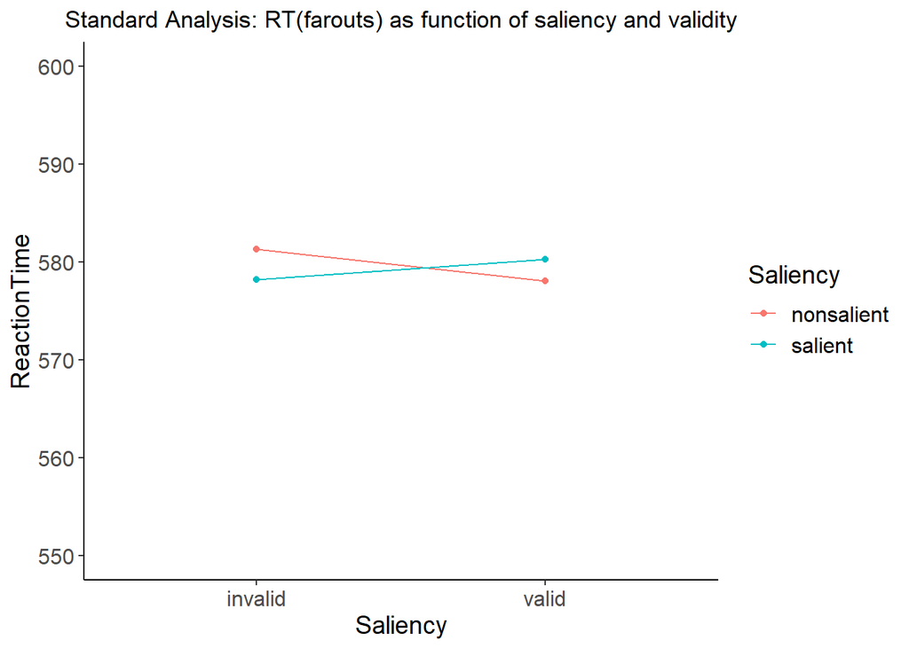

```r
#Plot for farouts

ggplot(aggmeanSV_fo, aes(x=Validity, color=Saliency, y=Mean))+
  geom_line(aes(group=Saliency))+
  geom_point()+
  labs(x="Saliency", y = "ReactionTime")+
  theme_classic()+
  ylim(550,600)+
  ggtitle("Standard Analysis: RT(farouts) as function of saliency and validity")+
  theme(plot.title = element_text(hjust = 0.5))+
  theme(legend.title = element_text(size=14), legend.text= element_text(size=12))+
  theme(axis.title = element_text(size=14),axis.text = element_text(size=12))
```

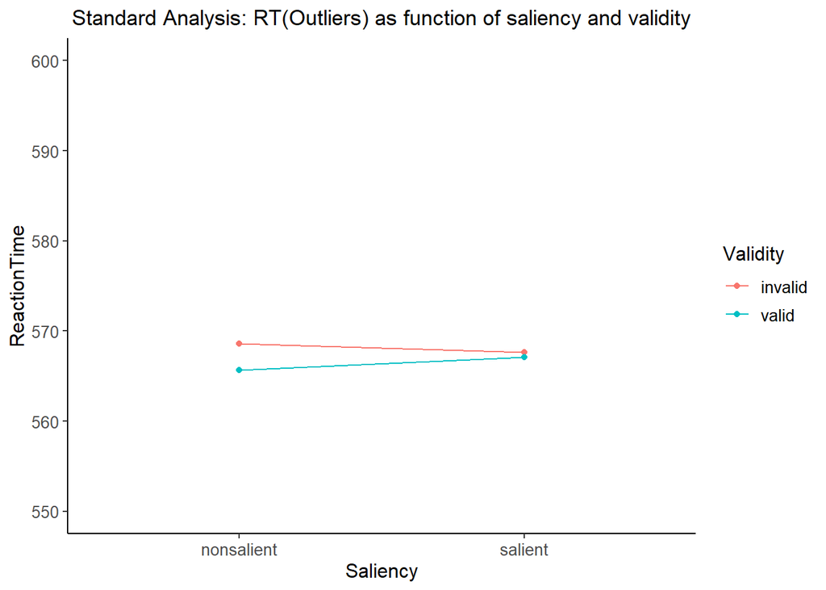

```r
#plot for outliers

ggplot(aggmeanSV_o, aes(x=Saliency, color=Validity, y=Mean))+
  geom_line(aes(group=Validity))+
  geom_point()+
  labs(x="Saliency", y = "ReactionTime")+
  theme_classic()+
  ylim(550,600)+
  ggtitle("Standard Analysis: RT(Outliers) as function of saliency and validity")+
  theme(plot.title = element_text(hjust = 0.5))+
  theme(legend.title = element_text(size=12), legend.text= element_text(size=10))+
  theme(axis.title = element_text(size=12),axis.text = element_text(size=10))
```

```r
anova_DistResp <- lm(RT_ifo~Validity+Saliency+ResponseType+ResponseType*Validity,data=Exp1agg_fo)
summary(anova_DistResp)
```

```
##
## Call:
## lm(formula = RT_ifo ~ Validity + Saliency + ResponseType + ResponseType *
##     Validity, data = Exp1agg_fo)
##
## Residuals:
##     Min      1Q  Median      3Q     Max
## -263.74  -68.44  -13.46   53.78  627.89
##
## Coefficients:
##                              Estimate Std. Error t value Pr(>|t|)
## (Intercept)                  580.8298     3.8942 149.152   <2e-16 ***
## Validityvalid                  0.7042     5.3846   0.131    0.896
## Saliencysalient               -5.7817     4.0161  -1.440    0.150
## ResponseTypeRR                -6.6057     8.5233  -0.775    0.438
## Validityvalid:ResponseTypeRR   4.3926    10.1060   0.435    0.664
## ---
## Signif. codes:  0 '***' 0.001 '**' 0.01 '*' 0.05 '.' 0.1 ' ' 1
##
## Residual standard error: 103.1 on 2634 degrees of freedom
## Multiple R-squared:  0.001084,   Adjusted R-squared:  -0.0004333
## F-statistic: 0.7143 on 4 and 2634 DF,  p-value: 0.5821
```

## Plot with ResponseTypeXSaliencyXValidity

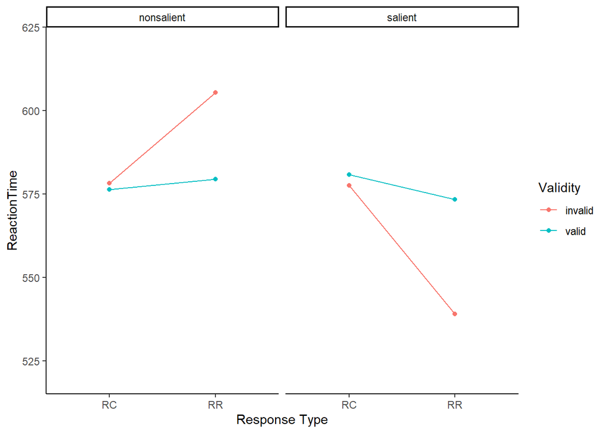

```r
ggplot(aggDistRespSV, aes(ResponseType,RTmean,color = Validity)) +
  geom_line(aes(group=Validity))+
  geom_point()+
  labs(x="Response Type", y = "ReactionTime")+
  ylim(520,620)+
  facet_grid(.~Saliency)+
  theme_classic()
```

## MULTI LEVEL MODELLING

### Trying the Multi level model

1. change to long format
2. Start with model 1 by having just one intercept

First creating amodel with just validity as an effect

```r
##Farouts
Model_Val <- lmer(RT_ifo~Validity + (1|participant), data = Exp1data_OL, REML = FALSE)
summary(Model_Val)
```

```
## Linear mixed model fit by maximum likelihood  ['lmerMod']
## Formula: RT_ifo ~ Validity + (1 | participant)
##    Data: Exp1data_OL
##
##      AIC      BIC   logLik deviance df.resid
## 165867.6 165897.6 -82929.8 165859.6    13449
##
## Scaled residuals:
##     Min      1Q  Median      3Q     Max
## -2.9769 -0.6356 -0.1552  0.4200  7.4349
##
## Random effects:
##  Groups      Name        Variance Std.Dev.
##  participant (Intercept)  5231     72.33
##  Residual                12975    113.91
## Number of obs: 13453, groups:  participant, 60
##
## Fixed effects:
##               Estimate Std. Error t value
## (Intercept)   579.7513     9.4407  61.409
## Validityvalid  -0.5544     1.9644  -0.282
##
## Correlation of Fixed Effects:
##             (Intr)
## Validityvld -0.104
```

```r
Model_valSal <- lmer(RT_ifo~Validity+Saliency+(1|participant), data = Exp1data_OL, REML = FALSE)
summary(Model_valSal)
```

```
## Linear mixed model fit by maximum likelihood  ['lmerMod']
## Formula: RT_ifo ~ Validity + Saliency + (1 | participant)
##    Data: Exp1data_OL
##
##      AIC      BIC   logLik deviance df.resid
## 165869.6 165907.1 -82929.8 165859.6    13448
##
## Scaled residuals:
##     Min      1Q  Median      3Q     Max
## -2.9752 -0.6356 -0.1554  0.4196  7.4366
##
## Random effects:
##  Groups      Name        Variance Std.Dev.
##  participant (Intercept)  5231     72.33
##  Residual                12975    113.91
## Number of obs: 13453, groups:  participant, 60
##
## Fixed effects:
##                 Estimate Std. Error t value
## (Intercept)     579.9405     9.4914  61.102
## Validityvalid    -0.5541     1.9644  -0.282
## Saliencysalient  -0.3791     1.9646  -0.193
##
## Correlation of Fixed Effects:
##             (Intr) Vldtyv
## Validityvld -0.104
## Salincyslnt -0.103 -0.001
```

```r
Model_VS_WP <- lmer(RT_ifo~Validity+Saliency+(1+participant)+(1|WordPair),data = Exp1data_OL, REML = FALSE)
summary(Model_VS_WP)
```

```
## Linear mixed model fit by maximum likelihood  ['lmerMod']
## Formula: RT_ifo ~ Validity + Saliency + (1 + participant) + (1 | WordPair)
##    Data: Exp1data_OL
##
##      AIC      BIC   logLik deviance df.resid
## 169963.8 170008.9 -84975.9 169951.8    13447
##
## Scaled residuals:
##     Min      1Q  Median      3Q     Max
## -2.0870 -0.6757 -0.1818  0.4324  7.6382
##
## Random effects:
##  Groups   Name        Variance Std.Dev.
##  WordPair (Intercept)   345     18.58
##  Residual             17924    133.88
## Number of obs: 13453, groups:  WordPair, 4
##
## Fixed effects:
##                   Estimate Std. Error t value
## (Intercept)     573.047297   9.907458  57.840
## Validityvalid    -0.619423   2.308569  -0.268
## Saliencysalient  -1.171157   2.308542  -0.507
## participant       0.018330   0.009206   1.991
##
## Correlation of Fixed Effects:
##             (Intr) Vldtyv Slncys
## Validityvld -0.117
## Salincyslnt -0.116 -0.001
## participant -0.283 -0.001 -0.001
```

```r
anova(Model_valSal, Model_VS_WP)
```

```
## Data: Exp1data_OL
## Models:
## Model_valSal: RT_ifo ~ Validity + Saliency + (1 | participant)
## Model_VS_WP: RT_ifo ~ Validity + Saliency + (1 + participant) + (1 | WordPair)
##              npar    AIC    BIC logLik deviance Chisq Df Pr(>Chisq)
## Model_valSal    5 165870 165907 -82930   165860
## Model_VS_WP     6 169964 170009 -84976   169952     0  1          1
```

```r
Model_VS_WP_Scr <- lmer(RT_ifo~Validity+Saliency+(1|participant) + (1|WordPair) +(1|Screen_bg), data = Exp1data_OL, REML = FALSE)
summary(Model_VS_WP_Scr)
```

```
## Linear mixed model fit by maximum likelihood  ['lmerMod']
## Formula:
## RT_ifo ~ Validity + Saliency + (1 | participant) + (1 | WordPair) +
##     (1 | Screen_bg)
##    Data: Exp1data_OL
##
##      AIC      BIC   logLik deviance df.resid
## 165873.0 165925.5 -82929.5 165859.0    13446
##
## Scaled residuals:
##     Min      1Q  Median      3Q     Max
## -2.9757 -0.6362 -0.1550  0.4189  7.4361
##
## Random effects:
##  Groups      Name        Variance Std.Dev.
##  participant (Intercept)  4950.7   70.36
##  WordPair    (Intercept)   112.8   10.62
##  Screen_bg   (Intercept)   223.7   14.96
##  Residual                12975.3  113.91
## Number of obs: 13453, groups:  participant, 60; WordPair, 4; Screen_bg, 2
##
## Fixed effects:
##                 Estimate Std. Error t value
## (Intercept)     578.5379    15.0390  38.469
## Validityvalid    -0.5539     1.9644  -0.282
## Saliencysalient  -0.3795     1.9646  -0.193
##
## Correlation of Fixed Effects:
##             (Intr) Vldtyv
## Validityvld -0.066
## Salincyslnt -0.065 -0.001
```

```r
Model_Dist <- lmer(RT_ifo~Validity+Saliency+(1|participant)+(1|Distance), data = Exp1data_OL, REML = FALSE)
```

```
## boundary (singular) fit: see ?isSingular
```

```r
summary(Model_Dist)
```

```
## Linear mixed model fit by maximum likelihood  ['lmerMod']
## Formula: RT_ifo ~ Validity + Saliency + (1 | participant) + (1 | Distance)
##    Data: Exp1data_OL
##
##      AIC      BIC   logLik deviance df.resid
## 165860.2 165905.3 -82924.1 165848.2    13446
##
## Scaled residuals:
##     Min      1Q  Median      3Q     Max
## -2.9751 -0.6356 -0.1553  0.4193  7.4363
##
## Random effects:
##  Groups      Name        Variance  Std.Dev.
##  participant (Intercept) 5.231e+03 7.233e+01
##  Distance    (Intercept) 9.019e-16 3.003e-08
##  Residual                1.298e+04 1.139e+02
## Number of obs: 13452, groups:  participant, 60; Distance, 14
##
## Fixed effects:
##                 Estimate Std. Error t value
## (Intercept)     579.9390     9.4915  61.101
## Validityvalid    -0.5511     1.9646  -0.281
## Saliencysalient  -0.3760     1.9648  -0.191
##
## Correlation of Fixed Effects:
##             (Intr) Vldtyv
## Validityvld -0.104
## Salincyslnt -0.103 -0.001
## convergence code: 0
## boundary (singular) fit: see ?isSingular
```

```r
Model_DistResp <- lmer(RT_ifo~Validity+Saliency+(1|participant)+(1|Distance)+(1|ResponseType), data = Exp1data_OL, REML = FALSE)
```

```
## boundary (singular) fit: see ?isSingular
```

```r
summary(Model_DistResp)
```

```
## Linear mixed model fit by maximum likelihood  ['lmerMod']
## Formula:
## RT_ifo ~ Validity + Saliency + (1 | participant) + (1 | Distance) +
##     (1 | ResponseType)
##    Data: Exp1data_OL
##
##      AIC      BIC   logLik deviance df.resid
## 165862.2 165914.8 -82924.1 165848.2    13445
##
## Scaled residuals:
##     Min      1Q  Median      3Q     Max
## -2.9751 -0.6356 -0.1553  0.4193  7.4363
##
## Random effects:
##  Groups       Name        Variance Std.Dev.
##  participant  (Intercept)  5231     72.33
##  Distance     (Intercept)     0      0.00
##  ResponseType (Intercept)     0      0.00
##  Residual                 12976    113.91
## Number of obs: 13452, groups:
## participant, 60; Distance, 14; ResponseType, 2
##
## Fixed effects:
##                 Estimate Std. Error t value
## (Intercept)     579.9390     9.4914  61.101
## Validityvalid    -0.5511     1.9646  -0.281
## Saliencysalient  -0.3760     1.9648  -0.191
##
## Correlation of Fixed Effects:
##             (Intr) Vldtyv
## Validityvld -0.104
## Salincyslnt -0.103 -0.001
## convergence code: 0
## boundary (singular) fit: see ?isSingular
```

```r
Model_DistRespLast <- lmer(RT_ifo~Validity+Saliency + (1|participant)+(1|LastOcc_Condition), data = Exp1data_OL,REML = FALSE)
```

```
## boundary (singular) fit: see ?isSingular
```

```r
summary(Model_DistRespLast)
```

```
## Linear mixed model fit by maximum likelihood  ['lmerMod']
## Formula:
## RT_ifo ~ Validity + Saliency + (1 | participant) + (1 | LastOcc_Condition)
##    Data: Exp1data_OL
##
##      AIC      BIC   logLik deviance df.resid
## 165860.2 165905.3 -82924.1 165848.2    13446
##
## Scaled residuals:
##     Min      1Q  Median      3Q     Max
## -2.9751 -0.6356 -0.1553  0.4193  7.4363
##
## Random effects:
##  Groups            Name        Variance Std.Dev.
##  participant       (Intercept)  5231     72.33
##  LastOcc_Condition (Intercept)     0      0.00
##  Residual                      12976    113.91
## Number of obs: 13452, groups:  participant, 60; LastOcc_Condition, 2
##
## Fixed effects:
##                 Estimate Std. Error t value
## (Intercept)     579.9390     9.4915  61.101
## Validityvalid    -0.5511     1.9646  -0.281
## Saliencysalient  -0.3760     1.9648  -0.191
##
## Correlation of Fixed Effects:
##             (Intr) Vldtyv
## Validityvld -0.104
## Salincyslnt -0.103 -0.001
## convergence code: 0
## boundary (singular) fit: see ?isSingular
```

```r
##intercept only model or null model
Model0 <- lmer(RT_ifo~1 + (1|participant), data = Exp1data_OL)
summary(Model0)
```

```
## Linear mixed model fit by REML ['lmerMod']
## Formula: RT_ifo ~ 1 + (1 | participant)
##    Data: Exp1data_OL
##
## REML criterion at convergence: 165853.4
##
## Scaled residuals:
##     Min      1Q  Median      3Q     Max
## -2.9796 -0.6347 -0.1562  0.4194  7.4321
##
## Random effects:
##  Groups      Name        Variance Std.Dev.
##  participant (Intercept)  5321     72.94
##  Residual                12975    113.91
## Number of obs: 13453, groups:  participant, 60
##
## Fixed effects:
##             Estimate Std. Error t value
## (Intercept)  579.473      9.468    61.2
```

```r
#to get a better picture of the result
#install.packages("jtools")
library(jtools)
summ(Model0)
```

```
## MODEL INFO:
## Observations: 13453
## Dependent Variable: RT_ifo
## Type: Mixed effects linear regression
##
## MODEL FIT:
## AIC = 165859.36, BIC = 165881.88
## Pseudo-R² (fixed effects) = 0.00
## Pseudo-R² (total) = 0.29
##
## FIXED EFFECTS:
## ---------------------------------------------------------
##                       Est.   S.E.   t val.    d.f.      p
## ----------------- -------- ------ -------- ------- ------
## (Intercept)         579.47   9.47    61.20   59.01   0.00
## ---------------------------------------------------------
##
## p values calculated using Satterthwaite d.f.
##
## RANDOM EFFECTS:
## ---------------------------------------
##     Group       Parameter    Std. Dev.
## ------------- ------------- -----------
##  participant   (Intercept)     72.94
##   Residual                    113.91
## ---------------------------------------
##
## Grouping variables:
## -------------------------------
##     Group      # groups   ICC
## ------------- ---------- ------
##  participant      60      0.29
## -------------------------------
```

```r
library(lmerTest)
ranova(Model0)
```

```
## ANOVA-like table for random-effects: Single term deletions
##
## Model:
## RT_ifo ~ (1 | participant)
##                   npar logLik    AIC    LRT Df Pr(>Chisq)
## <none>               3 -82927 165859
## (1 | participant)    2 -85083 170170 4312.6  1  < 2.2e-16 ***
## ---
## Signif. codes:  0 '***' 0.001 '**' 0.01 '*' 0.05 '.' 0.1 ' ' 1
```

```r
#with predictors
M1 <- lmer(RT_ifo~1+Validity+Saliency+(1+Validity+Saliency|participant), data = Exp1data_OL, REML = FALSE)
```

```
## boundary (singular) fit: see ?isSingular
```

```r
summary(M1)
```

```
## Linear mixed model fit by maximum likelihood . t-tests use
##   Satterthwaite's method [lmerModLmerTest]
## Formula: RT_ifo ~ 1 + Validity + Saliency + (1 + Validity + Saliency |
##     participant)
##    Data: Exp1data_OL
##
##      AIC      BIC   logLik deviance df.resid
## 165874.7 165949.8 -82927.4 165854.7    13443
##
## Scaled residuals:
##     Min      1Q  Median      3Q     Max
## -2.9257 -0.6358 -0.1582  0.4234  7.4880
##
## Random effects:
##  Groups      Name            Variance  Std.Dev. Corr
##  participant (Intercept)     5.561e+03  74.5694
##              Validityvalid   2.336e-02   0.1528 -1.00
##              Saliencysalient 1.879e+01   4.3350 -1.00  1.00
##  Residual                    1.297e+04 113.8884
## Number of obs: 13453, groups:  participant, 60
##
## Fixed effects:
##                   Estimate Std. Error         df t value Pr(>|t|)
## (Intercept)       579.9086     9.7763    60.0383  59.318   <2e-16 ***
## Validityvalid      -0.5613     1.9642 12815.1447  -0.286    0.775
## Saliencysalient    -0.3335     2.0424   403.5907  -0.163    0.870
## ---
## Signif. codes:  0 '***' 0.001 '**' 0.01 '*' 0.05 '.' 0.1 ' ' 1
##
## Correlation of Fixed Effects:
##             (Intr) Vldtyv
## Validityvld -0.111
## Salincyslnt -0.366  0.002
## convergence code: 0
## boundary (singular) fit: see ?isSingular
```

```r
summ(M1)
```

```
## MODEL INFO:
## Observations: 13453
## Dependent Variable: RT_ifo
## Type: Mixed effects linear regression
##
## MODEL FIT:
## AIC = 165874.70, BIC = 165949.77
## Pseudo-R² (fixed effects) = 0.00
## Pseudo-R² (total) = 0.29
##
## FIXED EFFECTS:
## ----------------------------------------------------------------
##                           Est.   S.E.   t val.       d.f.      p
## --------------------- -------- ------ -------- ---------- ------
## (Intercept)             579.91   9.78    59.32      60.04   0.00
## Validityvalid            -0.56   1.96    -0.29   12815.14   0.78
## Saliencysalient          -0.33   2.04    -0.16     403.59   0.87
## ----------------------------------------------------------------
##
## p values calculated using Satterthwaite d.f.
##
## RANDOM EFFECTS:
## -------------------------------------------
##     Group         Parameter      Std. Dev.
## ------------- ----------------- -----------
##  participant     (Intercept)       74.57
##  participant    Validityvalid      0.15
##  participant   Saliencysalient     4.33
##   Residual                        113.89
## -------------------------------------------
##
## Grouping variables:
## -------------------------------
##     Group      # groups   ICC
## ------------- ---------- ------
##  participant      60      0.30
## -------------------------------
```

```r
ranova(M1)
```

```
## boundary (singular) fit: see ?isSingular
```

```
## boundary (singular) fit: see ?isSingular
```

```
## ANOVA-like table for random-effects: Single term deletions
##
## Model:
## RT_ifo ~ Validity + Saliency + (1 + Validity + Saliency | participant)
##                                                     npar logLik    AIC
## <none>                                                10 -82927 165875
## Validity in (1 + Validity + Saliency | participant)    7 -82927 165869
## Saliency in (1 + Validity + Saliency | participant)    7 -82930 165874
##                                                        LRT Df Pr(>Chisq)
## <none>
## Validity in (1 + Validity + Saliency | participant) 0.0061  3     0.9999
## Saliency in (1 + Validity + Saliency | participant) 4.8591  3     0.1824
```

```r
M1A <- lmer(RT_ifo~1+Validity+Saliency+(1|participant), data =Exp1data_OL, REML = FALSE)
summary(M1A)
```

```
## Linear mixed model fit by maximum likelihood . t-tests use
##   Satterthwaite's method [lmerModLmerTest]
## Formula: RT_ifo ~ 1 + Validity + Saliency + (1 | participant)
##    Data: Exp1data_OL
##
##      AIC      BIC   logLik deviance df.resid
## 165869.6 165907.1 -82929.8 165859.6    13448
##
## Scaled residuals:
##     Min      1Q  Median      3Q     Max
## -2.9752 -0.6356 -0.1554  0.4196  7.4366
##
## Random effects:
##  Groups      Name        Variance Std.Dev.
##  participant (Intercept)  5231     72.33
##  Residual                12975    113.91
## Number of obs: 13453, groups:  participant, 60
##
## Fixed effects:
##                   Estimate Std. Error         df t value Pr(>|t|)
## (Intercept)       579.9405     9.4914    62.6698  61.102   <2e-16 ***
## Validityvalid      -0.5541     1.9644 13393.0784  -0.282    0.778
## Saliencysalient    -0.3791     1.9646 13393.1434  -0.193    0.847
## ---
## Signif. codes:  0 '***' 0.001 '**' 0.01 '*' 0.05 '.' 0.1 ' ' 1
##
## Correlation of Fixed Effects:
##             (Intr) Vldtyv
## Validityvld -0.104
## Salincyslnt -0.103 -0.001
```

```r
summ(M1A)
```

```
## MODEL INFO:
## Observations: 13453
## Dependent Variable: RT_ifo
## Type: Mixed effects linear regression
##
## MODEL FIT:
## AIC = 165869.57, BIC = 165907.10
## Pseudo-R² (fixed effects) = 0.00
## Pseudo-R² (total) = 0.29
##
## FIXED EFFECTS:
## ----------------------------------------------------------------
##                           Est.   S.E.   t val.       d.f.      p
## --------------------- -------- ------ -------- ---------- ------
## (Intercept)             579.94   9.49    61.10      62.67   0.00
## Validityvalid            -0.55   1.96    -0.28   13393.08   0.78
## Saliencysalient          -0.38   1.96    -0.19   13393.14   0.85
## ----------------------------------------------------------------
##
## p values calculated using Satterthwaite d.f.
##
## RANDOM EFFECTS:
## ---------------------------------------
##     Group       Parameter    Std. Dev.
## ------------- ------------- -----------
##  participant   (Intercept)     72.33
##   Residual                    113.91
## ---------------------------------------
##
## Grouping variables:
## -------------------------------
##     Group      # groups   ICC
## ------------- ---------- ------
##  participant      60      0.29
## -------------------------------
```

```r
#Next model with interaction
M2 <- lmer(RT_ifo~1+Saliency*Validity+(1|participant), data = Exp1data_OL, REML = FALSE)
summary(M2)
```

```
## Linear mixed model fit by maximum likelihood . t-tests use
##   Satterthwaite's method [lmerModLmerTest]
## Formula: RT_ifo ~ 1 + Saliency * Validity + (1 | participant)
##    Data: Exp1data_OL
##
##      AIC      BIC   logLik deviance df.resid
## 165869.5 165914.6 -82928.8 165857.5    13447
##
## Scaled residuals:
##     Min      1Q  Median      3Q     Max
## -2.9877 -0.6371 -0.1568  0.4224  7.4249
##
## Random effects:
##  Groups      Name        Variance Std.Dev.
##  participant (Intercept)  5232     72.33
##  Residual                12973    113.90
## Number of obs: 13453, groups:  participant, 60
##
## Fixed effects:
##                                Estimate Std. Error        df t value
## (Intercept)                     581.346      9.543    64.024  60.921
## Saliencysalient                  -3.196      2.784 13393.100  -1.148
## Validityvalid                    -3.356      2.776 13393.075  -1.209
## Saliencysalient:Validityvalid     5.611      3.928 13393.059   1.428
##                               Pr(>|t|)
## (Intercept)                     <2e-16 ***
## Saliencysalient                  0.251
## Validityvalid                    0.227
## Saliencysalient:Validityvalid    0.153
## ---
## Signif. codes:  0 '***' 0.001 '**' 0.01 '*' 0.05 '.' 0.1 ' ' 1
##
## Correlation of Fixed Effects:
##             (Intr) Slncys Vldtyv
## Salincyslnt -0.146
## Validityvld -0.146  0.500
## Slncyslnt:V  0.103 -0.709 -0.707
```

```r
summ(M2)
```

```
## MODEL INFO:
## Observations: 13453
## Dependent Variable: RT_ifo
## Type: Mixed effects linear regression
##
## MODEL FIT:
## AIC = 165869.53, BIC = 165914.57
## Pseudo-R² (fixed effects) = 0.00
## Pseudo-R² (total) = 0.29
##
## FIXED EFFECTS:
## ------------------------------------------------------------------------------
##                                         Est.   S.E.   t val.       d.f.      p
## ----------------------------------- -------- ------ -------- ---------- ------
## (Intercept)                           581.35   9.54    60.92      64.02   0.00
## Saliencysalient                        -3.20   2.78    -1.15   13393.10   0.25
## Validityvalid                          -3.36   2.78    -1.21   13393.07   0.23
## Saliencysalient:Validityvalid           5.61   3.93     1.43   13393.06   0.15
## ------------------------------------------------------------------------------
##
## p values calculated using Satterthwaite d.f.
##
## RANDOM EFFECTS:
## ---------------------------------------
##     Group       Parameter    Std. Dev.
## ------------- ------------- -----------
##  participant   (Intercept)     72.33
##   Residual                    113.90
## ---------------------------------------
##
## Grouping variables:
## -------------------------------
##     Group      # groups   ICC
## ------------- ---------- ------
##  participant      60      0.29
## -------------------------------
```